# Data Acquisition and Management Weekly Assignment - Wk10

Chun San Yip

2020/04/04

Overview: The assignment for this week is related to Text Mining. In this assignment, I start by getting the primary example code from chapter 2 of Text Mining with R working in an R Markdown document. I will then extend the code in two ways:

1. Work with a different corpus of my choosing, and
2. Incorporate at least one additional sentiment lexicon

All the code below are from the primary example code from the book: Text Mining with R - A Tidy Approach Julia Silge and David Robinson 2020-03-07 Creative Commons License This work by Julia Silge and David Robinson is licensed under a Creative Commons Attribution-NonCommercial-ShareAlike 3.0 United States License.

Load all the required packages.

```r
library(tidyverse)
library(tidytext)
library(textdata)
library(tidyr)
library(gutenbergr)
library(wordcloud)
```

Load all sentiments

```r
afinn <- get_sentiments("afinn")
bing <- get_sentiments("bing")
nrc <- get_sentiments("nrc")
```

As I don’t want to repeat the same corpus and data from “Text Mining with R - A Tidy Approach”, I just use the example to run through a new corpus. There is a Gutenberg project that we can use for corpus, I use one of my favourite book - Gulliver’s Travels into Several Remote Nations of the World by Jonathan Swift as my corpus

```r
gulliver <- gutenberg_download(829)
gbooks <- gulliver %>%
  mutate(linenumber = row_number(),
         chapter = cumsum(str_detect(text, regex("^chapter [\\divxlc]", ignore_case = TRUE)))) %>%
  unnest_tokens(word, text)
```

I also use the following example codes to generate sentiment comparison on 3 lexicons

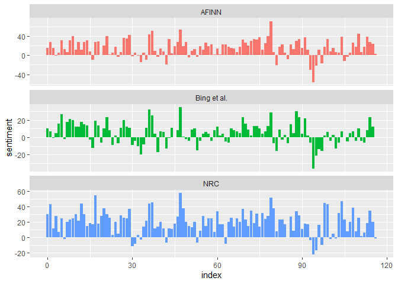

```r
afinn2 <- gbooks %>%
  inner_join(afinn) %>%
  group_by(index = linenumber %/% 80) %>%
  summarise(sentiment = sum(value)) %>%
  mutate(method = "AFINN")

bing_and_nrc2 <- bind_rows(gbooks %>%
                            inner_join(bing) %>%
                            mutate(method = "Bing et al."),
                           gbooks %>%
                            inner_join(nrc) %>%
                            filter(sentiment %in% c("positive",
                                                    "negative")) %>%
                            mutate(method = "NRC")) %>%
  count(method, index = linenumber %/% 80, sentiment) %>%
  spread(sentiment, n, fill = 0) %>%
  mutate(sentiment = positive - negative)

bind_rows(afinn2,
          bing_and_nrc2) %>%
  ggplot(aes(index, sentiment, fill = method)) +
  geom_col(show.legend = FALSE) +
  facet_wrap(~method, ncol = 1, scales = "free_y")
```

It looks like most parts of the book have positive sentiment except at the index of 93 to 95.

There is also a Loughran lexicon that was not used in the example code

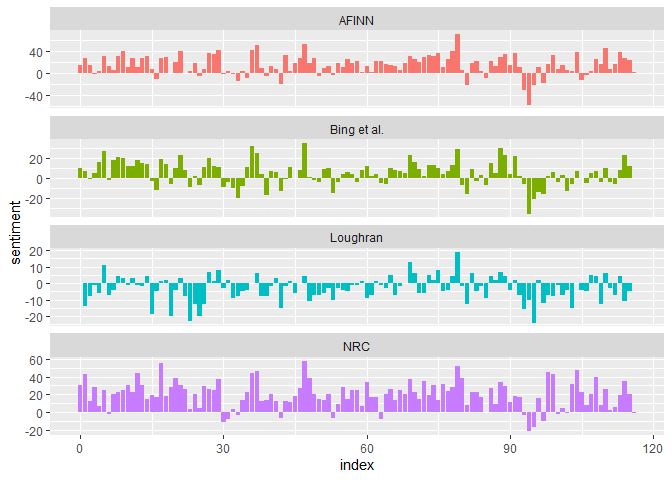

```r
loughran <- get_sentiments("loughran")

loughran2 <- gbooks %>%
            inner_join(loughran) %>%
            mutate(method = "Loughran")%>%
            count(method, index = linenumber %/% 80, sentiment) %>%
            spread(sentiment, n, fill = 0) %>%
            mutate(sentiment = positive - negative)

bind_rows(afinn2,
          bing_and_nrc2, loughran2) %>%
  ggplot(aes(index, sentiment, fill = method)) +
  geom_col(show.legend = FALSE) +
  facet_wrap(~method, ncol = 1, scales = "free_y")
```

Loughran has a lot more negative sentiments than the other 3 lexicons just by looking at the plot.

I would like to remove all the stop_words and see the most frequenct word I can find in the book. I also want to see the wordcloud generated from the data.

```r
data(stop_words)

gbooksStop <- gbooks %>%
  anti_join(stop_words) %>%
  count(word, sort=TRUE)

gbooksStop
```

```
## # A tibble: 7,766 x 2
##    word         n
##    <chr>    <int>
##  1 country    203
##  2 time       168
##  3 people     141
##  4 master     134
##  5 feet       121
##  6 majesty    111
##  7 found      110
##  8 hundred    109
##  9 court       99
## 10 _yahoos_    97
## # … with 7,756 more rows
```

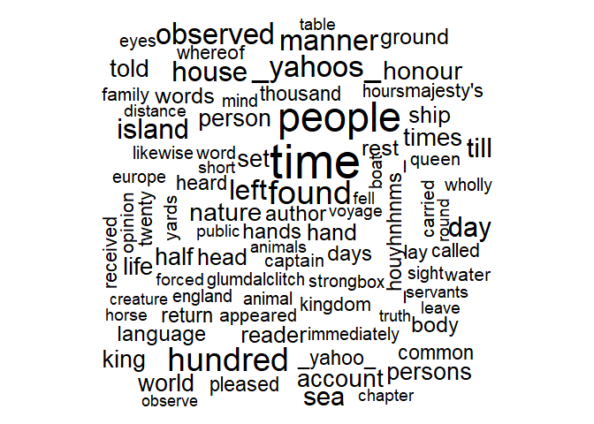

```r
gbooksStop %>%
  with(wordcloud(word, n, max.words = 100))
```

It’s really interesting to see country, time and people are the top 3 in the book!!! It is also interesting to see the wordcloud function generates different patterns and words everytime I re-run the function and the visual result may not align with the count.